HGG-oncohistones project [[source](https://github.com/fungenomics/HGG-oncohistones/blob/master/code/01B-human_hindbrain.Rmd)]

# 01B - Prepare human fetal hindbrain data

Selin Jessa []

08 September, 2022

# 1 Configuration

Configuration of project directory & analysis outputs:

**Show full config**

```r
source(here("rr_helpers.R"))

# Set up outputs
message("Document index: ", doc_id)
```

```
## Document index: 01B
```

```r
# Specify where to save outputs
out        <- here("output", doc_id); dir.create(out, recursive = TRUE)
figout     <- here("figures", doc_id); dir.create(figout, recursive = TRUE)
cache      <- paste0(readLines(here("include/project_root.txt")), basename(here()), "/", doc_id, "/")
```

Outputs and figures will be saved at these paths, relative to project root:

```
## public/output/01B
```

```
## public/figures/01B
```

Setting a random seed:

```r
set.seed(100)
```

# 2 Overview

In this analysis, we'll prepare the reference from the human fetal hindbrain data which has been processed with our single-cell workflow, and gather the required formats and outputs needed for comparisons to tumors:

- annotated Seurat objects, per-sample and integrated across samples
- gene signatures, per-cluster
- mean expression profiles, per-cluster

This data comes from [Bhaduri et al](http://dx.doi.org/10.1038/s41586-021-03910-8), and [Eze et al](http://dx.doi.org/10.1038/s41593-020-00794-1).

The structure of this document largely follows the analogous document for the thalamus (`01A`), however there are no published labels used for this brain region.

# 3 Libraries

```r
# Load libraries here
library(here)
library(tidyr)
library(dplyr)
library(readxl)
library(readr)
library(glue)
library(ggplot2)
library(magrittr)
library(purrr)
library(cowplot)
library(feather)
library(Seurat)
library(icytobox)
library(ggrepel)

source(here("include/style.R"))
source(here("code/functions/scRNAseq.R"))
ggplot2::theme_set(theme_min())
```

## 3.1 Metadata

```r
info_samples <- read_tsv(here("data/metadata/metadata_human_fetal_10X.tsv")) %>%
    filter(Region %in% c("Hindbrain", "Cerebellum"))

palette_sample <- info_samples %>% select(Sample, Sample_color) %>% tibble::deframe()
palette_alias  <- info_samples %>% select(Alias, Sample_color) %>% tibble::deframe()

ages <- info_samples$Age %>% unique %>% sort()
palette_age <- colorRampPalette(brewer.pal(8, "YlGnBu"))(n = length(ages))
names(palette_age) <- ages
```

## 3.2 QC

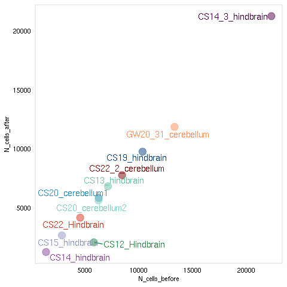

```r
qc_stats <- map_dfr(1:nrow(info_samples), ~ read_tsv(here(file.path(info_samples[.x, ]$Path, "preprocessing/seurat_metrics.tsv"))) %>%
                        tibble::add_column(.before = 1, Sample = info_samples[.x, ]$Sample))

#' a function to plot a scatterplot of 2 column in the aggregated qc dataframe
#'
#' @example qc_scatter(nCount_RNA_min.postQC, nCount_RNA_mean.postQC)
qc_scatter <- function(col1, col2) {

    col1_quo <- enquo(col1)
    col2_quo <- enquo(col2)

    qc_stats %>%
        ggplot(aes(x = !! col1_quo, y = !! col2_quo)) +
        geom_point(aes(color = Sample), size = 4, alpha = 0.5) +
        geom_text_repel(aes(label = Sample, color = Sample), size = 4) +
        scale_color_manual(values = palette_sample) +
        theme_min() +
        no_legend()

}

qc_scatter(N_cells_before, N_cells_after)
```

## 3.3 Prep objects

For each sample:

- load and plot the Seurat object
- count the number of cells in each cluster, and give each cluster a label prefixed w/ sample name
- add the correlations predictions to the object
- save the object

```r
prep_seurat <- function(path_to_sample) {

    message("@ ", basename(path_to_sample))

    # load the object as output by the SC workflow
    load(file.path(path_to_sample, "preprocessing/seurat.Rda"))

    # get the labels by correlations and add them to the Seurat object
    labels_cor <- read_tsv(file.path(path_to_sample, "correlations/ref.joint_mouse_extended/correlation.predicted_labels.tsv")) %>%
        tibble::column_to_rownames(var = "cell")
    seurat <- AddMetaData(seurat,
                          metadata = labels_cor,
                          col.name = c("COR_ref.joint_mouse_extended", "COR_ref.joint_mouse_extended_score"))

    # get some summary stats per cluster
    seurat[["Cluster_number"]] <- Idents(object = seurat)

    info_samples_cluster <- seurat@meta.data %>%
        group_by(Cluster_number) %>%
        mutate(N_cells = n()) %>%
        group_by(Cluster_number, N_cells) %>%
        summarize_at(vars(nCount_RNA, nFeature_RNA, percent.mito, percent.ribo, S.Score, G2M.Score), mean) %>%
        tibble::add_column(.before = 1, Sample = basename(path_to_sample)) %>%
        # add sample info table, and prefix the cluster number by the alias, so that it's unique
        # in the form, [Alias]_[Cluster]
        left_join(select(info_samples, Sample, Age, Alias), by = "Sample") %>%
        mutate(Cluster = paste0(Alias, "_", Cluster_number)) %>%
        select(Sample, Age, Alias, Cluster_number, Cluster, everything())

    # get the most common projection from the correlations (excluding the information
    # of the timepoint from the mouse clusters)
    best_match <- seurat@meta.data %>% rowwise() %>%
        mutate(Type = stringr::str_split_fixed(COR_ref.joint_mouse_extended, "_", 2) %>% getElement(2)) %>%
        group_by(Cluster_number, Type) %>%
        mutate(n = n()) %>%
        group_by(Cluster_number) %>% top_n(1, n) %>%
      slice(1) %>%
      select(Cluster_number, n, Type, COR_ref.joint_mouse_extended)

    # sanity check
    nrow(info_samples_cluster) == nrow(best_match)

    info_samples_cluster <- info_samples_cluster %>%
        left_join(best_match, by = "Cluster_number") %>%
        mutate(Prop_matched_mouse_atlas = round(n/N_cells, 2)) %>%
        select(-n) %>%
        mutate(ID_20210610 = paste0(Cluster, "_", Type)) %>%
        select(-Type)

    # put the unique cluster labels in the Seurat object
    seurat$Cluster <- plyr::mapvalues(seurat$Cluster_number,
                                      from = info_samples_cluster$Cluster_number,
                                      to = info_samples_cluster$Cluster)
    Idents(seurat) <- "Cluster"

    seurat$ID_20210610 <- plyr::mapvalues(seurat$Cluster_number,
                                          from = info_samples_cluster$Cluster_number,
                                          to = info_samples_cluster$ID_20210610)

    # correct the palette
    names(seurat@misc$colours) <- info_samples_cluster$Cluster

    # save the new seurat object
    # save(seurat, file = here(file.path(path_to_sample, "seurat.Rda")))

    return(info_samples_cluster)

}

# gather all cluster summary info
info_clusters <- map_dfr(1:nrow(info_samples), ~ prep_seurat(info_samples[.x, ]$Path))
write_tsv(info_clusters, glue("{out}/info_clusters.tsv"))
```

```r
info_clusters <- read_tsv(glue("{out}/info_clusters.tsv"))
```

## 3.4 Sample exclusions

No samples will be excluded due to low QC.

## 3.5 Per-cluster QC

```r
info_clusters %>% nrow()
```

```
## [1] 161
```

```r
info_clusters2 <- info_clusters %>%
    mutate(Note_sample = "OK",
           Note_cluster = case_when(
               N_cells < 30 ~ "Less than 30 cells",
               nCount_RNA < 1000 ~ "Low number of UMIs",
               percent.ribo > 50 ~ "High ribosomal content",
               TRUE ~ "OK"
           ))

info_clusters2 %>% filter(Note_sample == "OK" & Note_cluster == "OK") %>% nrow()
```

```
## [1] 141
```

```r
write_tsv(info_clusters2, glue("{out}/info_clusters2.tsv"))

# total # of cells
sum(info_clusters2$N_cells)
```

```
## [1] 79428
```

## 3.6 QC tables

```r
TABLE_hindbrain_qc <- info_samples %>%
    left_join(qc_stats, by = "Sample") %>%
    mutate(Publication = case_when(
        grepl("CS", Sample) ~ "Eze et al, Nature Neuroscience, 2021",
        grepl("GW", Sample) ~ "Bhaduri et al, Nature, 2021"
    )) %>%
    mutate(Note_sample = "OK") %>%
    select(
        # Sample info
        Sample, Age, Alias, Region, Publication,
        # QC
        # N_reads = `Number of Reads`,
        # N_cells_estimated = `Estimated Number of Cells`,
        N_cells_after_filtering = N_cells_after,
        # Reads_mapped_to_genome = `Reads Mapped to Genome`,
        # Reads_mapped_to_transcriptome = `Reads Mapped Confidently to Transcriptome`,
        Mean_mitochondrial_content_after_filtering = percent.mito_mean.postQC,
        Mean_UMIs_after_filtering = nCount_RNA_mean.postQC,
        Mean_N_genes_after_filtering = nFeature_RNA_mean.postQC,
        Max_mito_threshold = percent.mito_max.threshold,
        Min_N_genes_threshold = nFeature_RNA_min.threshold,
        Max_N_genes_threshold = nFeature_RNA_max.threshold,
        Max_UMIs_threshold = nCount_RNA_max.threshold,
        Note_sample)

rr_write_tsv(TABLE_hindbrain_qc,
             glue("{out}/TABLE_hindbrain_QC.tsv"),
             "Summary of sample info and QC for hindbrain samples")
```

```
## ...writing description of TABLE_hindbrain_QC.tsv to public/output/01B/TABLE_hindbrain_QC.desc
```

# 4 Gather gene signatures

First, load all cluster markers and filter out markers for samples/clusters that we'll exclude:

```r
clusters_keep <- info_clusters2 %>% filter(Note_cluster == "OK") %>% pull(Cluster)

cluster_markers <- map_dfr(1:nrow(info_samples), ~ read_tsv(here(file.path(info_samples[.x, ]$Path, "preprocessing/cluster_markers.tsv"))) %>%
                               tibble::add_column(Sample = info_samples[.x, ]$Sample)) %>%
    # get positive markers
    filter(avg_logFC > 0) %>%
    mutate(cluster = as.numeric(cluster)) %>%
    # add the cluster/sample info
    left_join(info_clusters2 %>% select(Sample, Cluster_number, Cluster), by = c("Sample" = "Sample", "cluster" = "Cluster_number")) %>%
    rename(Cluster_number = cluster) %>%
    # filter out excluded samples and clusters
    filter(Cluster %in% clusters_keep) %>%
    # get the diff between pct.1 and pct.2
    mutate(pct_diff = pct.1 - pct.2) %>%
    # reorder
    select(gene, pct_diff, everything())

# sanity checks
unique(cluster_markers$Cluster) %>% length()
```

```
## [1] 141
```

```r
all(cluster_markers$Cluster %in% clusters_keep)
```

```
## [1] TRUE
```

```r
head(cluster_markers)
```

| gene | pct_diff | p_val | avg_logFC | pct.1 | pct.2 | p_val_adj | Cluster_number | Sample | Cluster |
| --- | --- | --- | --- | --- | --- | --- | --- | --- | --- |
| ARL4A | 0.090 | 9.936107e-57 | 0.3064309 | 0.960 | 0.870 | 1.816618e-52 | 0 | CS13_hindbrain | CS13-H_0 |
| DDIT4 | 0.061 | 1.025524e-49 | 0.2540863 | 0.977 | 0.916 | 1.874966e-45 | 0 | CS13_hindbrain | CS13-H_0 |
| LDHA | 0.063 | 7.898211e-47 | 0.2648140 | 0.952 | 0.889 | 1.444030e-42 | 0 | CS13_hindbrain | CS13-H_0 |
| FGFBP3 | 0.130 | 6.428063e-39 | 0.2520210 | 0.865 | 0.735 | 1.175243e-34 | 0 | CS13_hindbrain | CS13-H_0 |
| SLC2A1 | 0.170 | 2.197159e-33 | 0.2939371 | 0.556 | 0.386 | 4.017066e-29 | 0 | CS13_hindbrain | CS13-H_0 |
| MCM5 | 0.149 | 4.477445e-33 | 0.2760484 | 0.355 | 0.206 | 8.186113e-29 | 0 | CS13_hindbrain | CS13-H_0 |

```r
# save
write_tsv(cluster_markers, glue("{out}/cluster_markers.tsv"))
```

Second, filter these down to 100-gene signatures:

```r
#' Create 100-gene signature given the markers for one cluster
filter_markers <- function(markers, sp = "hg", n_top = 100) {

    markers %>%
        # filter out mitochondrial and ribosomal genes
        dplyr::filter(., !grepl("RPS|RPL|MRPS|MRPL|^MT-", gene)) %>%
        group_by(Cluster) %>%
        # get positive markers
        dplyr::filter(avg_logFC > 0) %>%
        # sort by p-val
        arrange(p_val_adj) %>%
        # make sure they're unique
        distinct(gene, .keep_all = TRUE) %>%
        dplyr::slice(1:n_top) %>%
        ungroup()

}

# read gene annotation
anno <- read_tsv(here("data/misc/gene_annotation_with_homologous_mice_genes.txt"))
hindbrain_signatures_df <- cluster_markers %>%
    left_join(select(anno,
                     hsapiens_external_gene_id,
                     hsapiens_ensembl_gene_id,
                     mmusculus_external_gene_id,
                     mmusculus_ensembl_gene_id = mmusculus_homolog_ensembl_gene),
              by = c("gene" = "hsapiens_external_gene_id")) %>%
    filter_markers()
```

## 4.1 Signature QC

Compute some stats to assess how specific these are:

```r
# Sanity check
sort(table(hindbrain_signatures_df$Cluster))
```

```
##
##    CS13-H_0    CS15-H_2    CS13-H_1   CS14-H1_0    CS13-H_7    CS15-H_0
##           6           8          10          12          20          20
##   CS14-H1_1    CS19-H_5    CS15-H_3   CS14-H1_8   CS14-H1_9    CS13-H_4
##          23          23          27          33          34          35
##    CS19-H_9   CS14-H1_3   CS14-H1_6    CS13-H_5   CS13-H_11  CS14-H1_11
##          39          45          47          49          50          51
##  CS22-Cb_13   CS14-H2_2   CS22-Cb_3    CS13-H_3   CS13-H_13    CS22-H_0
##          52          54          56          63          73          73
##    CS15-H_7   GW20-Cb_0  CS20-Cb1_5  CS20-Cb2_0   CS14-H1_5   CS14-H1_4
##          76          76          84          84          85          86
##    CS19-H_3  CS14-H1_15    CS22-H_7    CS13-H_2  CS20-Cb1_0  CS14-H1_12
##          88          89          89          93          95          96
##   CS14-H2_9   CS14-H2_0   CS19-H_13  GW20-Cb_10   CS22-Cb_1   CS13-H_10
##          96          98          98          98          99         100
##   CS13-H_12    CS13-H_6    CS13-H_8    CS13-H_9  CS14-H1_10  CS14-H1_13
##         100         100         100         100         100         100
##  CS14-H1_14  CS14-H1_16  CS14-H1_17  CS14-H1_18   CS14-H1_2   CS14-H1_7
##         100         100         100         100         100         100
##   CS14-H2_1  CS14-H2_10   CS14-H2_3   CS14-H2_4   CS14-H2_5   CS14-H2_6
##         100         100         100         100         100         100
##   CS14-H2_7   CS14-H2_8    CS15-H_1    CS15-H_4    CS15-H_5    CS15-H_6
##         100         100         100         100         100         100
##    CS15-H_8    CS19-H_0    CS19-H_1   CS19-H_10   CS19-H_11   CS19-H_12
##         100         100         100         100         100         100
##   CS19-H_14   CS19-H_15   CS19-H_16   CS19-H_17   CS19-H_18   CS19-H_19
##         100         100         100         100         100         100
##    CS19-H_2    CS19-H_4    CS19-H_6    CS19-H_7    CS19-H_8  CS20-Cb1_1
##         100         100         100         100         100         100
## CS20-Cb1_10 CS20-Cb1_11  CS20-Cb1_2  CS20-Cb1_3  CS20-Cb1_4  CS20-Cb1_6
##         100         100         100         100         100         100
##  CS20-Cb1_7  CS20-Cb1_8  CS20-Cb1_9  CS20-Cb2_1 CS20-Cb2_10  CS20-Cb2_2
##         100         100         100         100         100         100
##  CS20-Cb2_3  CS20-Cb2_4  CS20-Cb2_6  CS20-Cb2_7  CS20-Cb2_8  CS20-Cb2_9
##         100         100         100         100         100         100
##   CS22-Cb_0  CS22-Cb_10  CS22-Cb_11  CS22-Cb_12   CS22-Cb_2   CS22-Cb_4
##         100         100         100         100         100         100
##   CS22-Cb_5   CS22-Cb_6   CS22-Cb_7   CS22-Cb_8   CS22-Cb_9    CS22-H_1
##         100         100         100         100         100         100
##   CS22-H_10   CS22-H_11   CS22-H_12   CS22-H_13    CS22-H_2    CS22-H_3
##         100         100         100         100         100         100
##    CS22-H_4    CS22-H_5    CS22-H_6    CS22-H_8    CS22-H_9   GW20-Cb_1
##         100         100         100         100         100         100
##  GW20-Cb_11  GW20-Cb_12  GW20-Cb_13  GW20-Cb_14  GW20-Cb_15  GW20-Cb_16
##         100         100         100         100         100         100
##  GW20-Cb_17  GW20-Cb_18  GW20-Cb_19  GW20-Cb_20   GW20-Cb_3   GW20-Cb_4
##         100         100         100         100         100         100
##   GW20-Cb_7   GW20-Cb_8   GW20-Cb_9
##         100         100         100
```

```r
hindbrain_signatures_df_qc <- hindbrain_signatures_df %>%
    group_by(Sample, Cluster) %>%
    summarise(median_logFC = median(avg_logFC),
              max_logFC = max(avg_logFC),
              n_gene_FC_above_1.5 = sum(avg_logFC > log2(1.5)),
              median_pct.1 = median(pct.1),
              median_pct.2 = median(pct.2)) %>%
    arrange(median_logFC)
# save intermediate files
write_tsv(hindbrain_signatures_df, glue("{out}/hindbrain_signatures_df.tsv"))
write_tsv(hindbrain_signatures_df_qc, glue("{out}/hindbrain_signatures_df_qc.tsv"))
```

We'll also want to remove erythrocyte & melanocyte clusters, which are quite biologically distinct:

```r
erythro_markers <- c("HBB", "HBA1", "HBA2", "HBZ", "HBG1")
(erythro_count <- cluster_markers %>% filter(gene %in% erythro_markers) %>% pull(Cluster) %>% table())
```

```
## .
## CS14-H1_15   CS15-H_7 GW20-Cb_20
##          4          4          4
```

```r
# remove the clusters with 4-5 of these markers:
erythro_clusters <- names(erythro_count)[erythro_count >= 4]

melano_markers <- c("DCT", "MITF", "PMEL")
(melano_count <- cluster_markers %>% filter(gene %in% melano_markers) %>% pull(Cluster) %>% table())
```

```
## .
##  CS13-H_12   CS13-H_8   CS13-H_9 CS14-H1_14 CS14-H2_10  CS14-H2_5  CS14-H2_7
##          1          1          1          1          1          1          1
## GW20-Cb_19
##          1
```

```r
# remove the clusters with all three of these:
melano_clusters <- names(melano_count)[melano_count == 3]
```

Filter out signatures which have outlier QC stats, indicative of non-specific signatures:

```r
hindbrain_signatures_df_qc_filt <- hindbrain_signatures_df_qc %>%
    filter(median_pct.2 < 0.4) %>%
    filter(n_gene_FC_above_1.5 > 10)

signatures_keep <- hindbrain_signatures_df_qc_filt$Cluster
length(signatures_keep)
```

```
## [1] 106
```

```r
info_clusters3 <- info_clusters2 %>%
    mutate(Note_cluster = case_when(
        Cluster %in% erythro_clusters ~ "Erythrocyte cluster, excluded",
        Cluster %in% melano_clusters ~ "Melanocyte cluster, excluded",
        TRUE ~ Note_cluster
    )) %>%
    mutate(Note_signature = case_when(
        Note_cluster != "OK" ~ "Excluded, see Note_sample/Note_cluster",
        !(Cluster %in% signatures_keep) ~ "Non-specific signature",
        TRUE ~ "OK"
    ))

write_tsv(info_clusters3, glue("{out}/info_clusters3.tsv"))

clusters_drop <- c(erythro_clusters, melano_clusters)
```

Convert to a list:

```r
hindbrain_signatures_df_filt <- hindbrain_signatures_df %>%
    filter(Cluster %in% signatures_keep & !(Cluster %in% clusters_drop))

hf_hindbrain_signatures <- list('hg_sym' = split(hindbrain_signatures_df, f = hindbrain_signatures_df$Cluster) %>% map(~ pull(.x, gene) %>% .[!is.na(.)]),
                               'hg_ens' = split(hindbrain_signatures_df, f = hindbrain_signatures_df$Cluster) %>% map(~ pull(.x, hsapiens_ensembl_gene_id) %>% .[!is.na(.)]))

save(hf_hindbrain_signatures, file = glue("{out}/hindbrain_signatures.Rda"))
```

# 5 Join data

Next, let's write out the config for integrating these samples:

```r
info_samples2 <- info_samples %>%
    select(Path, Sample = Alias, Age, Color = Sample_color) %>%
    mutate(Path = paste0(Path, "/seurat.Rda")) %>%
    write_tsv(glue("{out}/info.samples.tsv"))

info_groups <- data.frame("Covariate" = "Age",
                          "Levels" = unique(info_samples$Age),
                          "Color" = c("#7bccc4", "#ccebc5", "#fdd49e", "#fc8d59", "#ef6548", "#d7301f", "#b30000", "#7f0000")) %T>%
    write_tsv(glue("{out}/info.groups.tsv"))
```

## 5.1 Annotation

Make the annotation for the cell type projection scripts:

```r
# set cluster color as best-matching cluster in mouse atlas
palette_mouse_df <- palette_joint_mouse_extended %>% tibble::enframe()
cluster_palette_mouse_match <- info_clusters3 %>%
  left_join(palette_mouse_df, by = c("COR_ref.joint_mouse_extended" = "name")) %>%
  select(Cluster, value) %>%
  tibble::deframe()

# write annotation
cluster_palette_mouse_match %>%
  tibble::enframe("Cell_type", "Color") %>%
  write_tsv(glue("{out}/hf_hindbrain_annotation.tsv"))
```

# 6 Reproducibility

This document was last rendered on:

```
## 2022-09-08 14:54:02
```

The git repository and last commit:

```
## Local:    master /lustre06/project/6004736/sjessa/from_narval/HGG-oncohistones/public
## Remote:   master @ origin (git@github.com:fungenomics/HGG-oncohistones.git)
## Head:     [4101e76] 2022-09-08: Update README.md
```

The random seed was set with `set.seed(100)`

The R session info:

[output not shown]

The resources requested when this document was last rendered:

```
## #SBATCH --time=01:00:00
## #SBATCH --cpus-per-task=1
## #SBATCH --mem=50G
```

A project of the Kleinman Lab at McGill University, using the [rr](https://github.com/sjessa/rr/) reproducible research template.